# NWB Tutorial

Welcome to the Neurodata Without Borders (NWB) format official tutorial! NWB is a format for publishing and exchanging neuroscience data. The purpose of this tutorial is to demonstrate how to read and write data to NWB files. We will cover:

- the layout of an NWB file
- the primary NWB abstractions: `Module`, `Interface`, and `TimeSeries`
- NWB schemas and extensions
- the official NWB API

We will explore these concepts by analyzing some rodent hippocampal data and appending the result to an existing NWB file.

## Software Dependencies

This tutorial requires the following software:

- [NWB API](https://github.com/NeurodataWithoutBorders/api-python)
- [HDFView](https://www.hdfgroup.org/products/java/hdfview/), a graphical interface for browsing HDF5 files
- [Python](https://www.python.org/), version 2 or 3
- Python libraries:
  - [h5py](http://docs.h5py.org/en/latest/)
  - [scikit-learn](http://scikit-learn.org/stable/index.html)

## What is NWB for?

Neurophysiological data analysts are faced with many kinds of data. These may be divided into major types: (1) **metadata**, including subject type, device settings, experimental protocol and more; and (2) **primary data**, consisting of mainly numerical arrays. Metadata is sometimes descriptive of an entire experiment (e.g. subject characteristics), and sometimes descriptive of one or more specific arrays (e.g. stimulus descriptions for an array that numerically codes stimuli).

The aim of NWB is to place these diverse data within a single coherent structure. The established HDF5 format provides a solid, well-tested foundation; NWB thus defines a structure within the constraints of the familiar, filesystem-like hierarchy already provided by HDF5. The design principles informing this structure include:

- **human-readability**: Names of individual data elements should be comprehensible rather than cryptic. Deep hierarchies should be avoided where possible.
- **machine-readability**: the structure should be sufficiently constrained that APIs can be written against broad sets of NWB files
- **extensibility**: users can easily add new kinds of data to the format
- **one file per session**: individual NWB files should represent a single experimental "session", defined as a contiguous span of time.

To satisfy these principles, NWB strikes a balance between standardization and flexiblity. High and low-level file structures are fixed, but the medium level is free to vary. As we will see below, all NWB files contain the same top-level directories. You can always expect to find session-level metadata in the same location. Complex metadata (e.g. electrode maps) have a standard structure. And because most primary data are time series, NWB also provides a standard structure for time series. The choice of how to arrange the primary data is largely left up to individual users. This flexibility permits a single file to represent many possible data processing graphs.

## Tutorial Overview

In this tutorial, we will demonstrate one recommended way of using NWB. This method entails adding successive **modules** to a single file, with each module encapsulating a coherent set of data. We will work with data from one of the founding NWB datasets ([Buzsaki hc-3](https://crcns.org/data-sets/hc/hc-3)). The data are extracellular recordings from a rat running back and forth on a linear track to obtain a water reward. Embedded in the hippocampal formation are two different multielectrode arrays, each having 4 shanks, with each shank having 8 recording sites ("channels"). We only use a single session here, but the data from many similar sessions is hosted on [CRCNS](https://crcns.org/data-sets/hc/hc-3).

Working through the tutorial will give you experience working with the NWB API and reading, writing, and browsing an NWB file. Specifically, we are going to project the LFP into a new space (identified with independent component analysis) and segment the temporal dimension of the data into distinct trials (passes of the linear track). We will plot the projected LFP against animal position to reveal LFP features that selectively activate in specific locations across trials (behavior analogous to that of hippocampal place cells). Along the way, we will write our results and useful intermediates to the NWB file we start with. Because some of the data we will generate does not fit into pre-defined NWB structures, we will need to define an **extension** using the *specification language*.

[figure not shown]

Because the focus of this tutorial is on the mechanics of LFP files, rather than analysis, most of the code has been placed into an external module `buzsaki_hc`.

### (1) Review the Contents of the NWB File

First, let's orient ourselves to the structure of NWB. Open `ec014.468.nwb` with HDFView. You should see this:

[figure not shown]

Notice that there are 5 top-level datasets and 6 top-level groups. While most metadata is stored in the `/general` group, there are a few items that were judged important enough to include at the top level. These are the datasets:

- `file_create_date`: timestamp for the creation of this NWB file
- `identifier`: globally unique identifier for this NWB file
- `nwb_version`: version number for this NWB file
- `session_description`: a summary of the experiment that yielded the data stored in this file
- `session_start_time`: the absolute time at which the session began

The 6 groups contain the following kinds of data:

- `/acquisition`: Directly recorded data streams
- `/analysis`: free-form, unspecified data analysis products; intended for internal use, not publication. Published analysis products should be placed in a processing `Module` in `/processing`, with an accompanying `schema`.
- `/epochs`: Time slices of the experiment (e.g. subexperiments, trials)
- `/general`: Experimental metadata (e.g. protocol, notes, description of hardware)
- `/processing`: Data analysis products. `/processing` has a special structure that we cover in more detail below.
- `/stimulus`: Data pushed into the system (e.g. video stimulus, sound, voltage, etc) and/or secondary representations of that data (e.g. measurements of something used as a stimulus)

More details about these groups can be found in the [official documentation](http://neurodatawithoutborders.github.io/docs). In this tutorial, we are interested only in the contents of `/processing`. `/acquisition`, `/epochs`, and `/stimulus`, are empty for our session (the raw data would normally be present in `/acquisition`, but we do not provide it in order to keep the file size small).

#### /processing

The contents of `/processing` have the most complex structure in NWB. This is because `/processing` is intended to contain machine-readable representations of arbitrary analysis products. The contents of `/processing` are always a three-level hierarchy. A particular NWB abstraction corresponds to each level of the hierarchy.

- `Modules` are stored at the top-level of `/processing`. A `Module` is just an HDF5 group that declares its contents in an attribute `interfaces`. Because a `Module's` internal structure is fully described by the listed interfaces, `Modules` are not declared in a specification and may be named arbitrarily.
- `Interfaces` are the top-level contents of `Modules`. `Interfaces` are groups that contain a specific set of subgroups and/or datasets. Most interfaces contain one or more `TimeSeries` and related metadata. The contents of the `Interface` must be declared in the file's schema. Thus the name of the `Interface` group must match:
  - an entry in the containing `Module's` `interfaces` attribute
  - an `Interface` declaration in the file's schema
- `TimeSeries` are found inside `Interfaces` (and other places in an NWB file). A `TimeSeries` is a group that contains a time series and associated metadata. All `TimeSeries` are instances of an associated `TimeSeries` class, which is part of a hierarchy analogous to that of object-oriented programming languages. The core `TimeSeries` hierarchy is defined in the core NWB schema. It provides a set of `TimeSeries` intended to cover a broad range of data types. All `TimeSeries` must provide two key datasets:
  - `data`: contains the time-aligned data. Time must be on the first axis.
  - `timestamps` or `starting_time`: `timestamps` is a 1-dimensional dataset containing a timestamp for each row of `data`. These timestamps are relative to the experiment start time. Alternatively, `starting_time` is a single timestamp (also relative to experiment start time) that stores the start of the `TimeSeries`. `starting_time` must have an attribute `rate` which gives the sample rate. This allows the full list of timestamps to be derived from `starting_time`.

Now that we've reviewed the general structure of `/processing`, let's have a look at our file's `/processing` folder. Click on `/processing` in HDFView to examine its contents. You should see 2 groups inside: `published` and `filtered`. These are `Modules`. Click on `published`. Notice that its `interfaces` attribute (visible in the bottom pane of HDFView) has 6 entries: `Clustering`, `EventWaveform`, `FeatureExtraction`, `LFP`, `Position`, and `UnitTimes`. There is a subgroup corresponding to each entry. `Clustering`, `EventWaveform`, `FeatureExtraction`, and `UnitTimes` contain spike-related information. You can learn more about them in the [NWB docs](https://github.com/neurodatawithoutborders.github.io/docs). In this tutorial, we are concerned only with LFP and Position.

[figure not shown]

### (2) load the LFP and position data

```python
import h5py
data = h5py.File('ec014.468.nwb', 'r')
```

For the remainder of this tutorial, we will read our NWB file through the `File` object `data`. Now let's load the LFP time series. `h5py` provides it as a `Dataset` object that behaves similarly to a `numpy` array.

```python
lfp = data['/processing/filtered/FilteredEphys/theta/data']
```

Now let's load `position`:

```python
pos = data['/processing/filtered/Position/pca_1d/data']
```

## (3) Perform independent component analysis on the LFP

Independent Component Analysis is a technique for separating a multivariate signal into a set of additive components. Beginning with a set of observed signals, we model our signal at each time point as a linear combination of fixed basis functions. The contributions of the individual basis functions are assumed to be statistically independent. You can learn more about ICA [here](http://www.stat.ucla.edu/~yuille/courses/Stat161-261-Spring14/HyvO00-icatut.pdf). The model can be summarized as:

$$X = AS$$

Where $X$ is the "observed signal", $A$ is the "mixing matrix" (whose columns are the aforementioned basis functions), and $S$ is the "source signal" (with each row correpsonding to the coefficients for one basis function).

Here, our observed signal is the all-channel filtered LFP that we have loaded into `lfp`. The basis functions extracted from applying ICA to LFP signals have no straightforward physiological interpretation. However, when the LFPs are taken from the hippocampus of navigating rats, some of the basis functions behave like place cells; that is, their activities (given by the learned coefficients) are correlated to particular locations in the environment.

We call the `bhc` module to perform ICA for us. This yields two matrices: `sources` and `components`. Sources is $S$ in the model above, and components is $A^{-1}$.

```python
sources, components = bhc.lfp_ica(filt_lfp)
```

## (4) Plot Component Activation vs Position

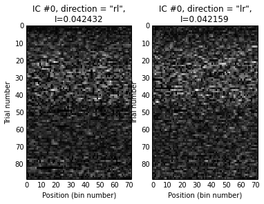

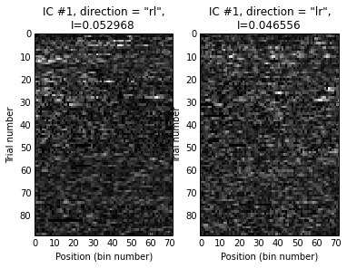

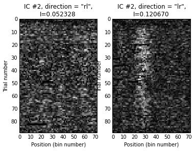

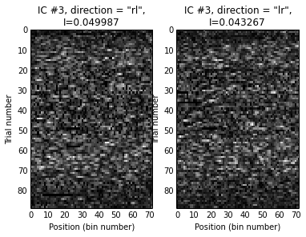

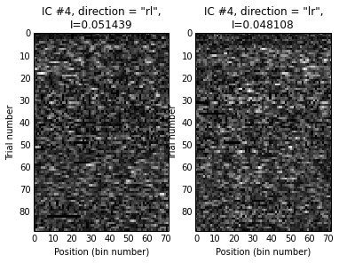

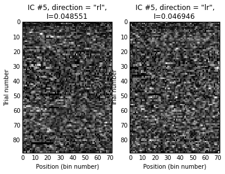

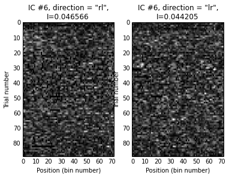

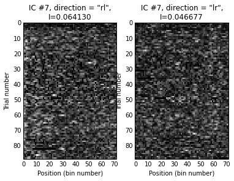

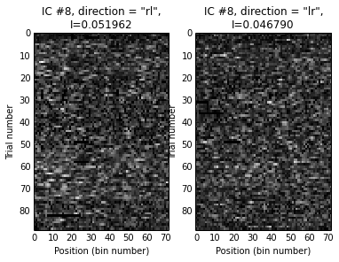

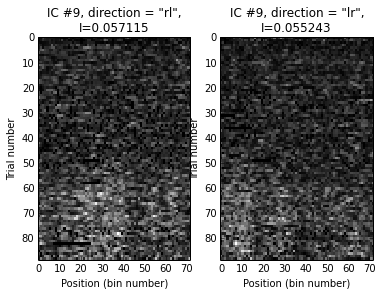

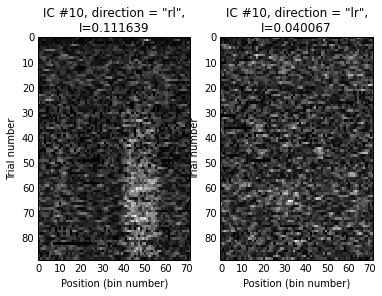

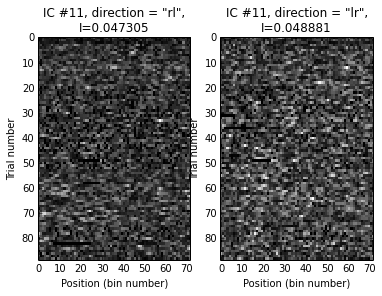

[52 more figures not shown]

```python
bhc.plot_source_heatmaps(sources, trials)
```